# The spline thing

Kenny Ye

One of the reviewers made the following comments on the original manuscript “Apparent threshold for dose-response relationship - It ispleasing to see a dose-response relationship between pack-years of smoking and mutation burden. The authors’ claim of a threshold at which this relationship ceases is less convincing. Presumably this is a post hoc analysis (ie defined after seeing the data, rather than specified a priori) - in which case it suffers the risk of inflated type 1 error rates (and should therefore require a more stringent p value). The grid search methodology for the optimal threshold in particular would seem prone to such inflation - a better approach would be to fit a cubic spline to the relationship as an exploratory tool; test whether the spline fit is better than the linear fit; and show confidence intervals plus fitted curve for the spline in the figure.”

Theoretially, the B-spline can be incorporated into generalized linear model. A cubic spline for B-spline is order 4 with a number of knots that satistifies, nbasis = norder + nknots - 2. A piecewise linear model is equivalent to a order 2 B-spline with 1 knot. And our change point model is a special case of order-2 B-spline with a non-fixed knot, and a second segment being flat.

Here we will incorporate the regular 2-degree B-spline with no restriction.

```r
setwd("~/Dropbox/Spivack/Somatic_Mutation/Revision")
mutations <- read.csv("Lung_mutation_061621.csv")

names(mutations)[c(15, 19)] <- c("SNV_sensitivity", "INDEL_sensitivity")
names(mutations)[c(13, 17)] <- c("SNV_observed", "INDEL_observed")
names(mutations)[c(14, 18)] <- c("SNV_surveyed_genome", "INDEL_surveyed_genome")
names(mutations)[8] <- "Quit_years"
names(mutations)[11] <- "ULD"
names(mutations)[12] <- "CancerType"

mutations$Smoking_group <- factor(mutations$Smoking_group, levels = c("Never", "Light",
    "Moderate", "Heavy"))

mutations$SNV_perCell.a <- mutations$SNV_perCell * mutations$SNV_sensitivity
mutations$INDEL_perCell.a <- mutations$INDEL_perCell * mutations$INDEL_sensitivity

observed <- aggregate(SNV_observed ~ Individual, mutations, sum)
surveyed_genome <- aggregate(SNV_surveyed_genome ~ Individual, mutations, sum)[,
    2]
surveyed_genome_adjusted <- aggregate(I(SNV_surveyed_genome * SNV_sensitivity) ~
    Individual, mutations, sum)[, 2]

SNV <- data.frame(observed, surveyed_genome, surveyed_genome_adjusted)
SNV <- data.frame(SNV, mutations[match(SNV[, 1], mutations[, 2]), c(3:12)])
```

### load some R packages

```r
library(ggplot2)
library(MASS)
library(lme4)
```

### 1320 Smoking Squamous COPD 81yr 59 smoking years, 6 pack years, highest number of mutations

### Generalized linear model (negative binomials)

#### all cells from an individuals are merged

```r
SNVa <- subset(SNV, Individual != "Bulk1320")

########################## With never-smokers ###

dev0 <- -glm.nb(SNV_observed ~ Age + offset(log(surveyed_genome_adjusted)), data = SNVa)$twologlik
dev1 <- -glm.nb(SNV_observed ~ Age + Smoking_pack_year + offset(log(surveyed_genome_adjusted)),
    data = SNVa)$twologlik


### Order-4 Bspline, Cubic with one knot by default in the middle There is little
### need to optimize the knot.  knot in the middle

x <- SNVa$Smoking_pack_year
bs <- create.bspline.basis(c(0, 116), nbasis = 5, norder = 4)
glm.spline <- glm.nb(SNV_observed ~ I(Age - 40) + eval.basis(x, bs) - 1 + offset(log(surveyed_genome_adjusted)),
    data = SNVa)

dev.o4 <- -as.numeric(summary(glm.spline)$twologlik)

### p-value of order-4 B-spline compared to null model

1 - pchisq(dev0 - dev.o4, 4)
```

```
## [1] 0.0001273551
```

```r
### p-value of order-4 B-spline compared to the linear model

1 - pchisq(dev1 - dev.o4, 3)
```

```
## [1] 0.0003210482
```

### general piecewise linear model using B-spline

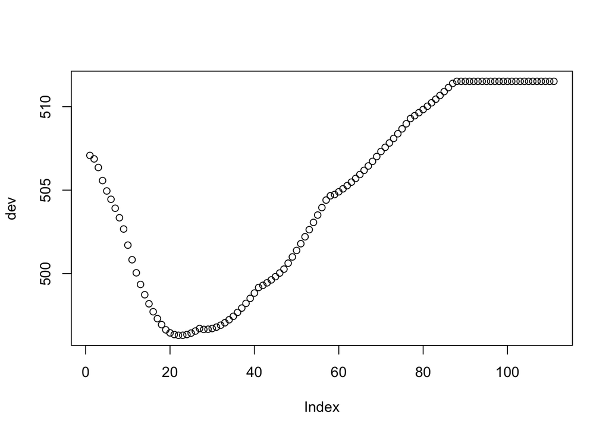

```r
x <- SNVa$Smoking_pack_year
dev <- c()
for (tau in seq(5, 115, 1)) {
    bs <- create.bspline.basis(c(0, 116), nbasis = 3, norder = 2, breaks = c(0, tau,
        116))
    glm.fit <- glm.nb(SNV_observed ~ Age + eval.basis(x, bs) - 1 + offset(log(surveyed_genome_adjusted)),
        data = SNVa)
    dev <- c(dev, -glm.fit$twologlik)
}

plot(dev)
abline(h = dev0)
abline(h = dev1)
```

```r
### the best change point
tau.hat <- seq(5, 115, 1)[which.min(dev)]
tau.hat
```

```
## [1] 26
```

```r
dev2 <- min(dev)

### 95% confidence interval
range(seq(5, 115, 1)[dev < min(dev) + qchisq(0.95, 1)])
```

```
## [1] 16 50
```

```r
## p-value from LLR test

## compare to the null model
1 - pchisq(dev0 - dev2, 3)
```

```
## [1] 8.683924e-05
```

```r
## compare to the linear model
1 - pchisq(dev1 - dev2, 2)
```

```
## [1] 0.0001957496
```

```r
## fit the model
x.a <- x - tau.hat
x.a[x < tau.hat] <- 0
glm.fit <- glm.nb(SNV_observed ~ Age + x + x.a + offset(log(surveyed_genome_adjusted)),
    data = SNVa)

summary(glm.fit)$coef
```

```
##                 Estimate  Std. Error    z value     Pr(>|z|)
## (Intercept) -14.97257716 0.164971361 -90.758645 0.000000e+00
## Age           0.01478432 0.003068361   4.818312 1.447778e-06
## x             0.03110996 0.006048348   5.143547 2.695987e-07
## x.a          -0.03758529 0.008194712  -4.586530 4.506736e-06
```

```r
### threshold model (with same changing point)
x.a <- x
x.a[x > tau.hat] <- tau.hat
glm.fit1 <- glm.nb(SNV_observed ~ Age + x.a + offset(log(surveyed_genome_adjusted)),
    data = SNVa)

anova(glm.fit1, glm.fit)
```

```
## Likelihood ratio tests of Negative Binomial Models
##
## Response: SNV_observed
##                                                   Model    theta Resid. df
## 1     Age + x.a + offset(log(surveyed_genome_adjusted)) 10.77094        29
## 2 Age + x + x.a + offset(log(surveyed_genome_adjusted)) 12.28604        28
##      2 x log-lik.   Test    df LR stat.    Pr(Chi)
## 1       -500.5791
## 2       -496.3031 1 vs 2     1 4.275954 0.03865526
```

### Generalized Mixed Linear Models (negative binomial)

```r
### null model
glmer0 <- glmer.nb(SNV_observed ~ I(Age - 40) + offset(log(SNV_surveyed_genome *
    SNV_sensitivity)) + (1 | Individual), data = mutations, subset = !is.element(Individual,
    "Bulk1320"))
dev0 <- -2 * as.numeric(summary(glmer0)$logLik)

### linear model
glmer1 <- glmer.nb(SNV_observed ~ I(Age - 40) + Smoking_pack_year + offset(log(SNV_surveyed_genome *
    SNV_sensitivity)) + (1 | Individual), data = mutations, subset = !is.element(Individual,
    "Bulk1320"))
dev1 <- -2 * as.numeric(summary(glmer1)$logLik)

### Linear model vs null model
anova(glmer0, glmer1)
```

```
## Data: mutations
## Subset: !is.element(Individual, "Bulk1320")
## Models:
## glmer0: SNV_observed ~ I(Age - 40) + offset(log(SNV_surveyed_genome *
## glmer0:     SNV_sensitivity)) + (1 | Individual)
## glmer1: SNV_observed ~ I(Age - 40) + Smoking_pack_year + offset(log(SNV_surveyed_genome *
## glmer1:     SNV_sensitivity)) + (1 | Individual)
##        npar    AIC    BIC  logLik deviance  Chisq Df Pr(>Chisq)
## glmer0    4 1824.1 1835.5 -908.05   1816.1
## glmer1    5 1823.5 1837.8 -906.77   1813.5 2.5524  1     0.1101
```

### Order-4 Bspline, Cubic with one knot by default in the middle

#### There is little need to optimize the knot.

```r
### knot in the middle

bs <- create.bspline.basis(c(0, 116), nbasis = 5, norder = 4)
x <- mutations[, "Smoking_pack_year"]
mutations[, c("bspl4.1", "bspl4.2", "bspl4.3", "bspl4.4", "bspl4.5")] <- eval.basis(x,
    bs)
glmer.spline <- glmer.nb(SNV_observed ~ I(Age - 40) + bspl4.1 + bspl4.2 + bspl4.3 +
    bspl4.4 + bspl4.5 - 1 + offset(log(SNV_surveyed_genome * SNV_sensitivity)) +
    (1 | Individual), data = mutations, subset = !is.element(Individual, "Bulk1320"))

dev.o4 <- -2 * as.numeric(summary(glmer.spline)$logLik)


### p-value of the change point model compared to null model

1 - pchisq(dev0 - dev.o4, 4)
```

```
## [1] 0.003424873
```

```r
### p-value of the change point compared to the linear model

1 - pchisq(dev1 - dev.o4, 3)
```

```
## [1] 0.004295841
```

### select change point based on the random effect model

#### search for the change point with B-spline equivalent of piecewise linear model

#### order 2 with one knot

```r
x <- mutations$Smoking_pack_year
dev <- c()
for (tau in seq(5, 115, 1)) {
    bs <- create.bspline.basis(c(0, 116), nbasis = 3, norder = 2, breaks = c(0, tau,
        116))
    glmer1 <- glmer.nb(SNV_observed ~ I(Age - 40) + eval.basis(x, bs) - 1 + offset(log(SNV_surveyed_genome *
        SNV_sensitivity)) + (1 | Individual), data = mutations, subset = !is.element(Individual,
        "Bulk1320"))
    dev <- c(dev, -2 * as.numeric(summary(glmer1)$logLik))
}

plot(dev)
abline(h = dev0)
abline(h = dev1)
abline(h = min(dev) + qchisq(0.95, 1), lty = 2)

### the best change point
tau.hat <- seq(10, 115, 1)[which.min(dev)]
tau.hat

dev2 <- min(dev)

### confidence interval for the change point

range(seq(5, 115, 1)[dev < min(dev) + qchisq(0.95, 1)])

### p-value of the change point model compared to null model

1 - pchisq(dev0 - min(dev), 3)

### p-value of the change point compared to the linear model

1 - pchisq(dev1 - min(dev), 2)

x.a <- x - tau.hat
x.a[x < tau.hat] <- 0
glmer.fit <- glmer.nb(SNV_observed ~ I(Age - 55) + x + x.a + offset(log(SNV_surveyed_genome *
    SNV_sensitivity)) + (1 | Individual), data = mutations, subset = !is.element(Individual,
    "Bulk1320"))

summary(glmer.fit)$coef
```

[output not shown]

### a bit tricky because of the differences in age and in the coverage

### will overlay on projected number of mutations with 100% coverage/sensitivity

### also at the geometric mean of age

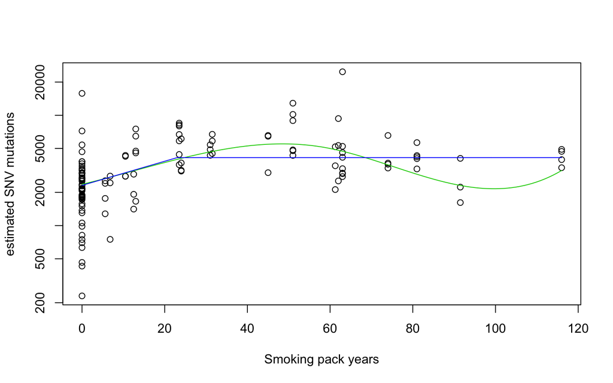

```r
### treshold model

tau.hat <- 23

x <- mutations$Smoking_pack_year
x.a <- x
x.a[x > tau.hat] <- tau.hat
glmer1a <- glmer.nb(SNV_observed ~ I(Age - 40) + x.a + offset(log(SNV_surveyed_genome *
    SNV_sensitivity)) + (1 | Individual), data = mutations, subset = !is.element(Individual,
    "Bulk1320"))

xx <- x[which(!is.element(mutations$Individual, "Bulk1320"))]


### cubic spline model glmer.spline


mutations.a <- subset(mutations,Individual!="Bulk1320")

plot(mutations.a$Smoking_pack_year, mutations.a$SNV_perCell,log="y",xlab="Smoking pack years",ylab="estimated SNV mutations")

bs <- create.bspline.basis(c(0,116),nbasis=5,norder=4)
wgl <- mean((mutations$SNV_surveyed_genome*mutations$SNV_sensitivity)/(mutations$SNV_observed/mutations$SNV_perCell))
m.age <- exp(mean(log(SNVa$Age)))

### estimate of the fixed effects
bhat <- coef(glmer.spline)$Individual[1,2:7]
### design matrix
XX <- cbind(m.age-40,eval.basis(bs,0:116))

lines(0:116,wgl*exp(XX %*% t(bhat)),lty=1,col=3)

x.a <- 0:116
x.a[x.a > tau.hat] <- tau.hat
b <- apply(coef(glmer1a)$Individual,2,mean)

linear.threshold.fits <- wgl*exp(b[1]+x.a * b[3]  + b[2]*(m.age-40))

lines(0:116,linear.threshold.fits,lty=1,col=4)
```

### Confidence Interval for Spline

Let $\hat{\beta}$ be the coefficients of the B-spline basis, given the covariance matrix of $\hat{\beta}$, we have $var(a'\hat{\beta}) = a' var(\hat{\beta}) a$. From the standard error, we can obtain a confidence interval from the normal approximation.

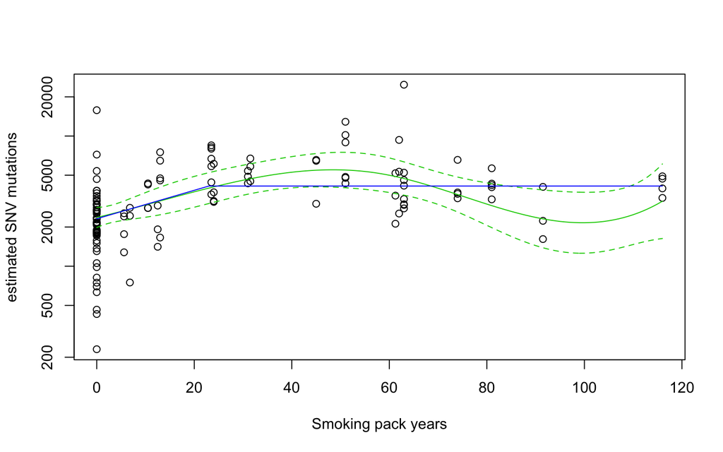

```r
### covariance matrix

W <- summary(glmer.spline)$vcov

se <- sqrt(diag(XX %*% W %*% t(XX)))

mm <- XX %*% t(bhat)
upper <- wgl*exp(1.96*se + mm)
lower <- wgl*exp(-1.96*se + mm)

plot(mutations.a$Smoking_pack_year, mutations.a$SNV_perCell,log="y",xlab="Smoking pack years",ylab="estimated SNV mutations")
lines(0:116,wgl*exp(XX %*% t(bhat)),lty=1,col=3)
lines(0:116,upper,lty=2,col=3)
lines(0:116,lower,lty=2,col=3)
lines(0:116,linear.threshold.fits,lty=1,col=4)
```

### Export data for plots

```r
linePlots <- data.frame(0:116, wgl * exp(mm), lower, upper, linear.threshold.fits)
names(linePlots) <- c("pack_years", "spline", "spline.lower", "spline.upper", "linear_threshold")
write.csv(linePlots, file = "model_fits.csv", quote = F, row.names = F)
```